# ESM206 lab5

Shuhan Song

October 29, 2019

#### Lab 5 objectives

- learn to parse dates with ‘lubridate’
- get counts of observations with count()
- Uncount() rows
- One and two-sample t-test
- Create a heatmap with geom_tile()

use tidyr::uncount() to convert out lobster data from frequency format to case format

```r
lobster_tidy <- lobster_abundance %>%
  tidyr::uncount(lobster_count) # repeat each row "count" times, removed count=0 rows, can use fcn populate to find the eliminated rows
```

#### Exploratory data visualization

We’re only going to consider “site” as our variable of interest

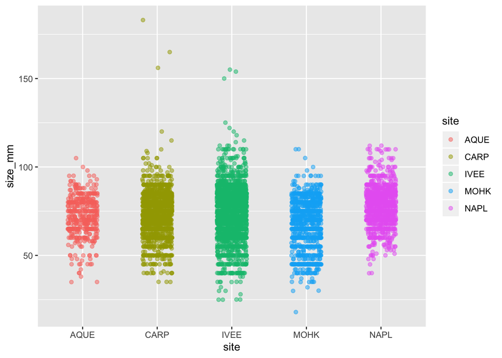

```r
ggplot(lobster_tidy, aes(x = site, y = size_mm)) +
  geom_jitter(aes(color = site),
              alpha = 0.5,
              width = 0.2)
```

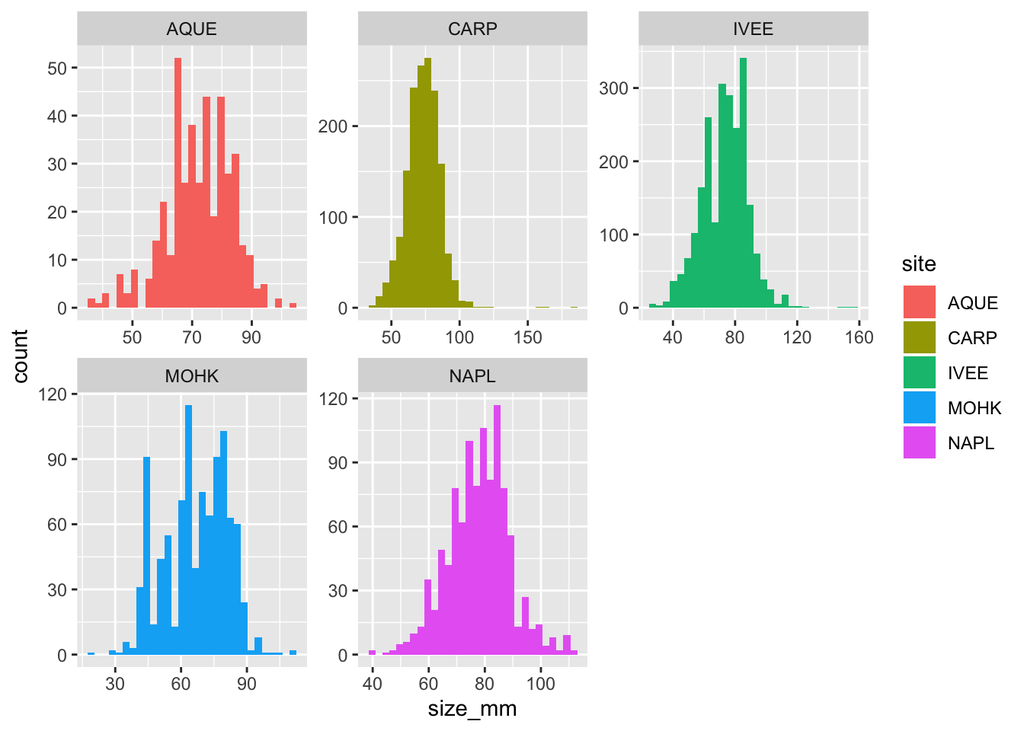

```r
#histogram
ggplot(lobster_tidy, aes(x = size_mm)) +
  geom_histogram(aes(fill = site)) +
  facet_wrap(~site, scales = "free") # scale fit the data in each group. only use when not comparing across groups
```

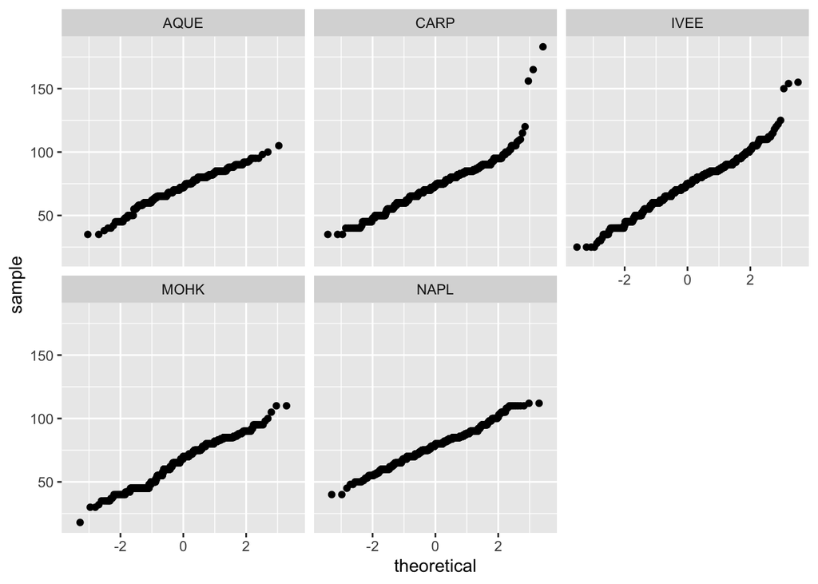

```r
# QQ plot
ggplot(lobster_tidy, aes(sample = size_mm)) +
  geom_qq()+
  facet_wrap(~site)
```

```r
# don't let outliers influence decisions on whether it's normal distribution or not.
# the slop is not meaningful. only LINEAR relatinship matters. linear means normal distribution
```

#### Convert the “data” column to class “Date”

We’ll use the ‘lubridate’ packages to convert to data format, and then to help us easily parse month & years

```r
lobster_date <- lobster_tidy %>%
  mutate(
    date_new = lubridate::mdy(date) #mdy - month day year, can also use other combination
  )
```

Now let’s parse year and month using lubridate::month() and lubridate::year()

```r
lobster_parse_date <- lobster_date %>%
  mutate(
    obs_month = lubridate::month(date_new, label = TRUE), # default is to pull the month as NUMBER!! # label = TRUE will replace the month number with abbreviation and automatically recognized it as an ordered factor
    obs_year = lubridate::year(date_new)
  )
levels(lobster_parse_date$obs_month) # even just two month included, recognized all levels
```

```
##  [1] "Jan" "Feb" "Mar" "Apr" "May" "Jun" "Jul" "Aug" "Sep" "Oct" "Nov"
## [12] "Dec"
```

Now let’s find counts of observed lobsters based on different hierarchical groupings:

count lobsters by year and month

```r
# count by month
lobster_ym <- lobster_parse_date %>%
  dplyr::count(obs_year, obs_month) # first group by year, then grouped by month

lobster_ym
```

```
## # A tibble: 8 x 3
##   obs_year obs_month     n
##      <dbl> <ord>     <int>
## 1     2012 Aug         231
## 2     2013 Aug         243
## 3     2014 Aug         404
## 4     2014 Sep         106
## 5     2015 Aug        1100
## 6     2016 Aug         809
## 7     2017 Aug        1668
## 8     2018 Aug        1805
```

```r
# count by year
lobster_y <- lobster_parse_date %>%
  dplyr::count(obs_year)

lobster_y
```

```
## # A tibble: 7 x 2
##   obs_year     n
##      <dbl> <int>
## 1     2012   231
## 2     2013   243
## 3     2014   510
## 4     2015  1100
## 5     2016   809
## 6     2017  1668
## 7     2018  1805
```

```r
# count by site
lobster_site <- lobster_parse_date %>%
  dplyr::count(site)
lobster_site
```

```
## # A tibble: 5 x 2
##   site      n
##   <chr> <int>
## 1 AQUE    422
## 2 CARP   1619
## 3 IVEE   2304
## 4 MOHK    982
## 5 NAPL   1039
```

```r
# count by site and transect
```

note: make the data in tidy format so that users can analyze the data as they prefer

If we want to create a summary table that contains statistics other than counts by group. It’s easier to use group_by() + n()

```r
lobster_summary <- lobster_parse_date %>%
  group_by(site) %>%
  summarize(
    lobster_number = n(), # find counts
    mean_size = mean(size_mm, na.rm = TRUE),
    sd_size = sd(size_mm, na.rm = TRUE)
  )
lobster_summary
```

```
## # A tibble: 5 x 4
##   site  lobster_number mean_size sd_size
##   <chr>          <int>     <dbl>   <dbl>
## 1 AQUE             422      72.3    11.4
## 2 CARP            1619      72.8    12.5
## 3 IVEE            2304      73.6    14.4
## 4 MOHK             982      66.9    14.2
## 5 NAPL            1039      78.2    11.1
```

#### Find confidence intervals

Use t.test() to find CI (for one sample) and perform t-tests to compare means of two samples (this will cover conceptually in lectures week 6)

```r
ivee_lobster <- lobster_tidy %>%
  filter(site == "IVEE") %>%
  pull(size_mm) # pull() create a vector that contains all size_mm

t.test(ivee_lobster) # use for a vector containing many numbers
```

```
##
##  One Sample t-test
##
## data:  ivee_lobster
## t = 245.23, df = 2302, p-value < 2.2e-16
## alternative hypothesis: true mean is not equal to 0
## 95 percent confidence interval:
##  72.99130 74.16806
## sample estimates:
## mean of x
##  73.57968
```

95% CI: If take many samples of the population, expect 95% of the samples contain the true population mean

#### Two-sample t-test to compare means

We want to ask: is there a significant difference in lobster lengths at Naples and Mohawk reefs?

We’ve done our necessary exploratory analyses (normal, sample size) to determine that a 2-sample t-test for means comparison is appropriate.

- give t-test the entire samples, not the samply means

```r
napl_sample <- lobster_tidy %>%
  filter(site == "NAPL") %>%
  pull(size_mm)

mohk_sample <- lobster_tidy %>%
  filter(site == "MOHK") %>%
  pull(size_mm)

mn_ttest <- t.test(mohk_sample, napl_sample) # in either direction, are the two data significantly, different
# Welch: the two samples do not have the same variance

# 95% CI: true sample differences between individuals in each group
```

```r
lobster_mn <- lobster_tidy %>%
  filter(site %in% c("NAPL", "MOHK"))

mn_ttest2 <- t.test(size_mm ~ site, data = lobster_mn) # t test on size_mm between two levels in "site" in lobster_mn
mn_ttest2
```

```
##
##  Welch Two Sample t-test
##
## data:  size_mm by site
## t = -19.849, df = 1850.8, p-value < 2.2e-16
## alternative hypothesis: true difference in means is not equal to 0
## 95 percent confidence interval:
##  -12.43436 -10.19806
## sample estimates:
## mean in group MOHK mean in group NAPL
##           66.86833           78.18454
```

Instead:

Here is the p-value: 1.215407810^{-79}  
Here is the t-statistic: -19.8487322

#### Heat map

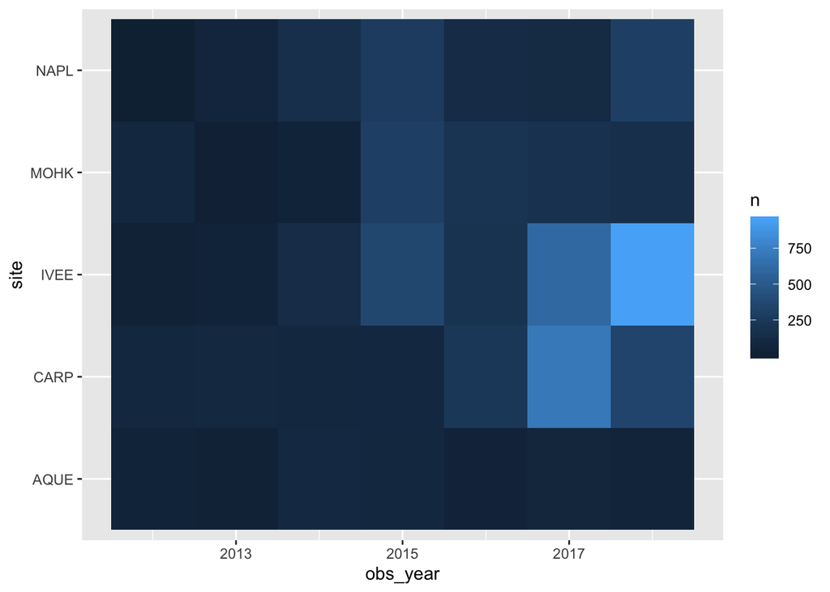

```r
lobster_ys <- lobster_parse_date %>%
  count(obs_year, site)


ggplot(data = lobster_ys, aes(x = obs_year, y = site)) +
  geom_tile(aes(fill = n))
```